# Question

los Juegos Europeos se realizan cada cuatro años y en estos participan países de Europa, alternando las sedes deportivas. La tabla muestra algunos datos de las últimas cinco versiones de los Juegos Europeos:

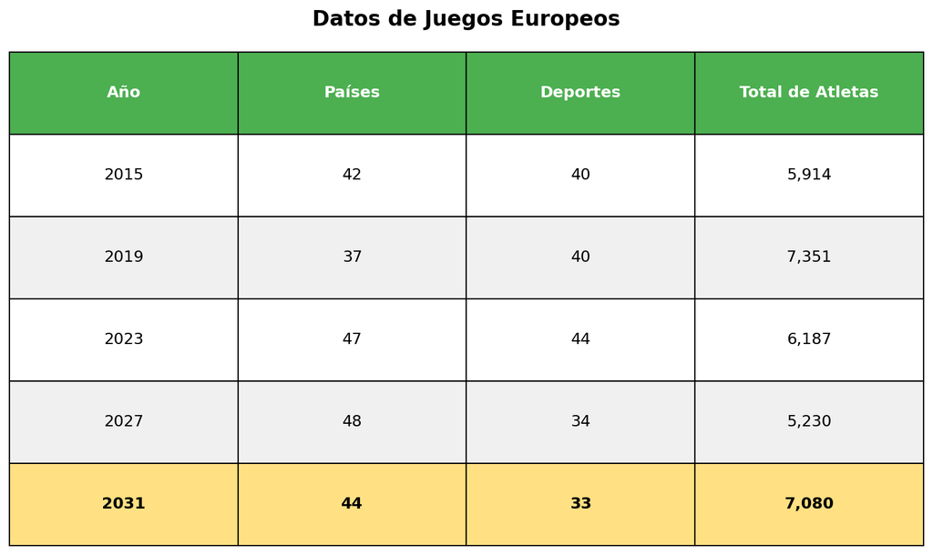

Del total de atletas participantes en 2031, el 6% compite en atletismo. Para determinar el número de atletas atletas ese año, se sugiere multiplicar 0.06 por el número de atletas que participaron en 2031. El procedimiento sugerido es:

## Answerlist

- suficiente para determinar el número de atletas que participó en atletismo en el año 2031
- insuficiente, porque falta considerar el número total de deportes en el evento
- incorrecto, pues se debe multiplicar 0.6 por el número de atletas de 2031
- insuficiente, porque falta multiplicar el resultado por el número de países participantes en 2031

# Solution

Para resolver este problema, necesitamos evaluar si el procedimiento propuesto para calcular el número de atletas que compiten en atletismo es matemáticamente correcto y suficiente.

### Análisis del procedimiento propuesto

**Datos disponibles:**

- Total de atletas en 2031: 7,080
- Porcentaje que compite en atletismo: 6%
- Procedimiento sugerido: multiplicar 0.06 por 7,080

### Verificación matemática

El cálculo de un porcentaje de una cantidad total se realiza multiplicando el porcentaje (expresado como decimal) por la cantidad total:

**Cálculo:** 6% de 7,080 = 0.06 × 7,080 = 425

Por lo tanto, aproximadamente 425 atletas compitieron en atletismo en 2031.

### Evaluación de cada opción

**Análisis de la respuesta correcta:**

El procedimiento es **suficiente** porque:

1. Tenemos el dato del total de atletas en 2031
2. Conocemos el porcentaje exacto que compite en atletismo (6%)
3. La multiplicación 0.06 × 7,080 nos da directamente el número buscado
4. No se requiere información adicional para este cálculo

### Conclusión

El procedimiento sugerido (multiplicar 0.06 por el total de atletas) es matemáticamente correcto y contiene toda la información necesaria para determinar el número de atletas que compitieron en atletismo en 2031.

## Answerlist

- Verdadero
- Falso
- Falso
- Falso

# Meta-information

exname: juegos_deportivos_interpretacion_representacion extype: schoice exsolution: 1000 exshuffle: TRUE exsection: Estadística|Análisis de datos|Porcentajes|Interpretación de tablas exextra[Type]: Interpretación y representación exextra[Level]: 2 exextra[Language]: es exextra[Course]: Matemáticas ICFES